# K-Means

# Tarea 4.

# Realizada por: Karen Bolaños Alfaro

# Ejercicios

Librerías

```r
library(tidyverse)
library(visdat)
library(GGally)
library(reshape2)
library(gridExtra)
```

1. Desarolle el Análisis del Problema

El dataset Wholesale Customers contiene datos de clientes de un distribuidor al por mayor que muestra el gasto anual en unidades monetarias para diferentes categorías de productos.

El dataset contiene 440 observaciones y 8 atributos o columnas y no presenta valores faltantes.

**Descripción de los atributos**  
1) FRESH: gasto anual en productos frescos (continua);  
2) MILK: gasto anual en productos lácteos (continua);  
3) GROCERY: gasto anual en comestibles (continua);  
4) FROZEN: gasto anual en productos congelados (continua)  
5) DETERGENTS_PAPER: gasto anual en detergentes y productos de papel (continua)  
6) DELICATESSEN: gasto anual en productos delicatessen (continua);  
7) CHANNEL: tipo de cliente que adquiere los productos- Horeca (Hotel/Restaurant/CafÃ©) or Retail channel (Nominal)  
8) REGION: Region: Lisnon, Oporto or Other (Nominal)

| REGIÓN | Frecuencia |
| --- | --- |
| Lisbon | 77 |
| Oporto | 47 |
| Otras Regiones | 316 |
| Total | 440 |

| CANAL | Frecuencia |
| --- | --- |
| Horeca | 298 |
| Retail | 142 |
| Total | 440 |

Fuente del dataset: https://archive.ics.uci.edu/ml/datasets/Wholesale+customers

Basado en el dataset anterior realice un modelo k-means que agrupe los clientes en 5 grupos basado en el consumo de productos fresh, milk, grocery, frozen, detergent paper y delicatessen

2. Cargue el archivo Wholesale customers data.csv en una variable

```r
wholesale_customers <- read.csv("Wholesale.csv")
```

3. Desarolle el Entendimiento de los Datos

```r
# veamos el tipo de los datos
glimpse(wholesale_customers)
```

```
## Observations: 440
## Variables: 8
## $ Channel          <int> 2, 2, 2, 1, 2, 2, 2, 2, 1, 2, 2, 2, 2, 2, 2, 1,…
## $ Region           <int> 3, 3, 3, 3, 3, 3, 3, 3, 3, 3, 3, 3, 3, 3, 3, 3,…
## $ Fresh            <int> 12669, 7057, 6353, 13265, 22615, 9413, 12126, 7…
## $ Milk             <int> 9656, 9810, 8808, 1196, 5410, 8259, 3199, 4956,…
## $ Grocery          <int> 7561, 9568, 7684, 4221, 7198, 5126, 6975, 9426,…
## $ Frozen           <int> 214, 1762, 2405, 6404, 3915, 666, 480, 1669, 42…
## $ Detergents_Paper <int> 2674, 3293, 3516, 507, 1777, 1795, 3140, 3321, …
## $ Delicassen       <int> 1338, 1776, 7844, 1788, 5185, 1451, 545, 2566, …
```

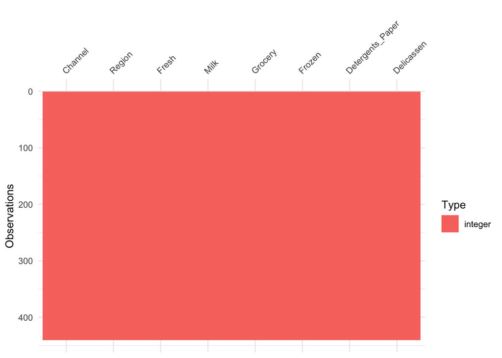

```r
# todos los datos son de tipo integer y no tenemos NA
vis_dat(wholesale_customers)
```

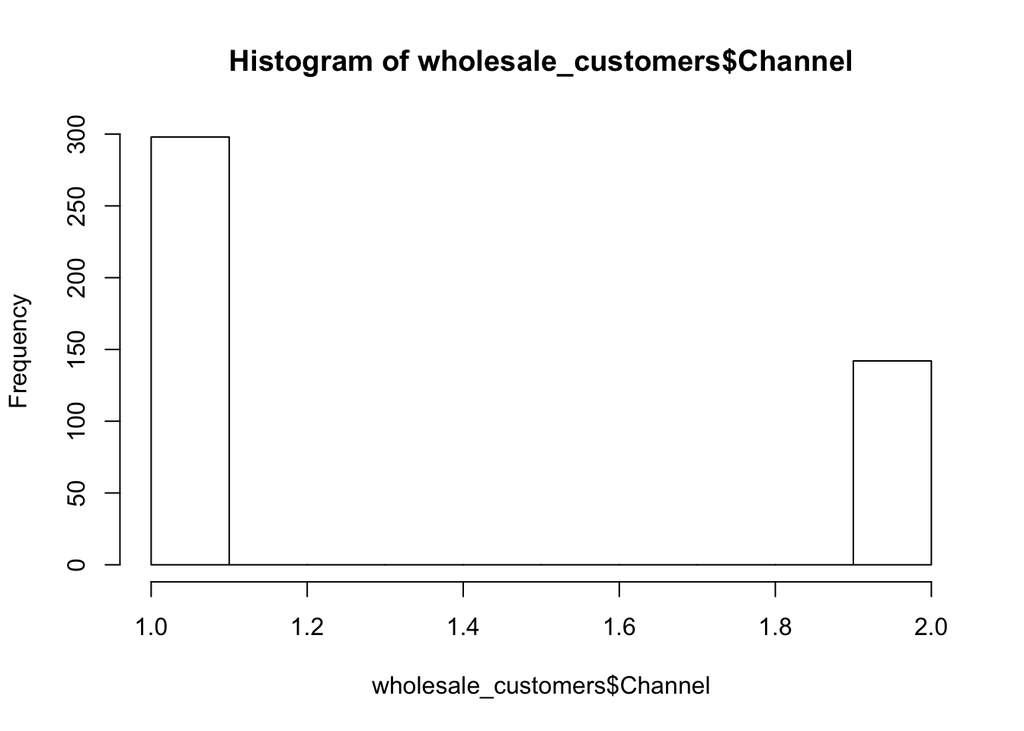

```r
# histograma para determinar qué numero corresponde a qué channel
hist(wholesale_customers$Channel)
```

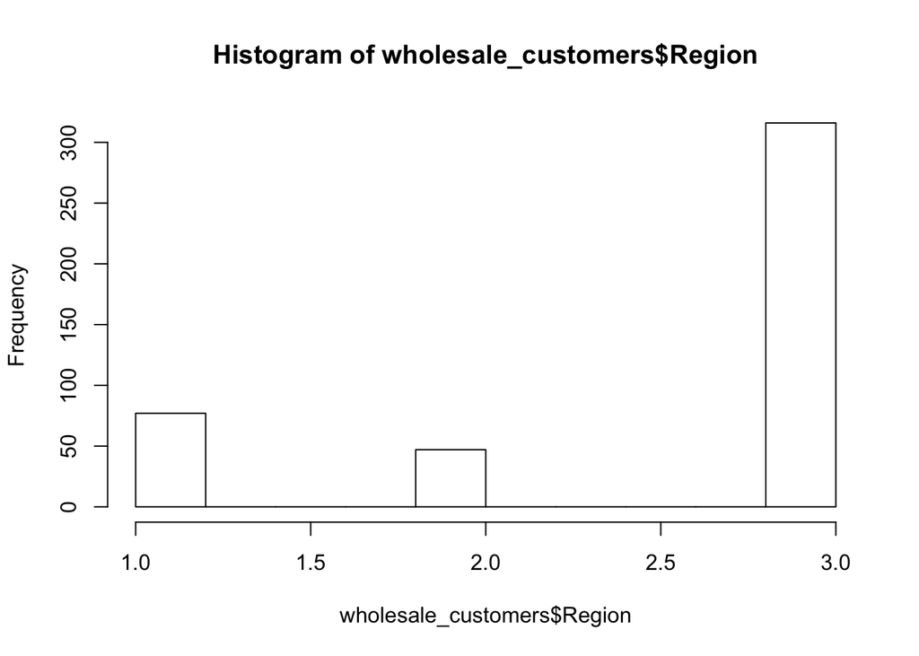

```r
# Horeca    298 --> 1
# Retail    14 --> 2

hist(wholesale_customers$Region)
```

```r
# Lisbon    77 --> 1
# Oporto    47  --> 2
# Other Region  316  --> 3

summary(wholesale_customers)
```

```
##     Channel          Region          Fresh             Milk
##  Min.   :1.000   Min.   :1.000   Min.   :     3   Min.   :   55
##  1st Qu.:1.000   1st Qu.:2.000   1st Qu.:  3128   1st Qu.: 1533
##  Median :1.000   Median :3.000   Median :  8504   Median : 3627
##  Mean   :1.323   Mean   :2.543   Mean   : 12000   Mean   : 5796
##  3rd Qu.:2.000   3rd Qu.:3.000   3rd Qu.: 16934   3rd Qu.: 7190
##  Max.   :2.000   Max.   :3.000   Max.   :112151   Max.   :73498
##     Grocery          Frozen        Detergents_Paper    Delicassen
##  Min.   :    3   Min.   :   25.0   Min.   :    3.0   Min.   :    3.0
##  1st Qu.: 2153   1st Qu.:  742.2   1st Qu.:  256.8   1st Qu.:  408.2
##  Median : 4756   Median : 1526.0   Median :  816.5   Median :  965.5
##  Mean   : 7951   Mean   : 3071.9   Mean   : 2881.5   Mean   : 1524.9
##  3rd Qu.:10656   3rd Qu.: 3554.2   3rd Qu.: 3922.0   3rd Qu.: 1820.2
##  Max.   :92780   Max.   :60869.0   Max.   :40827.0   Max.   :47943.0
```

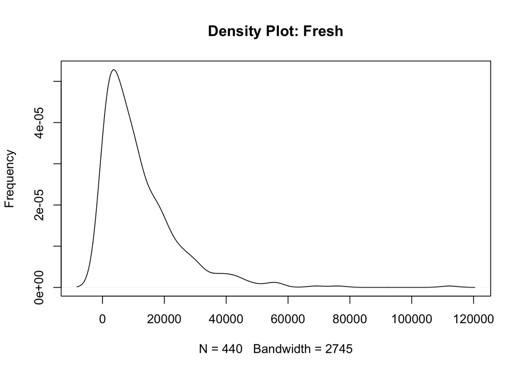

```r
# gráficos de densidad para ver el comportamiento de los datos
plot(density(wholesale_customers$Fresh), main = "Density Plot: Fresh", ylab = "Frequency")
```

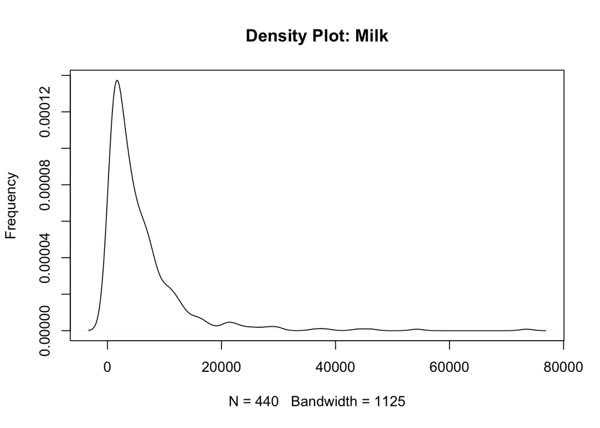

```r
plot(density(wholesale_customers$Milk), main = "Density Plot: Milk", ylab = "Frequency")
```

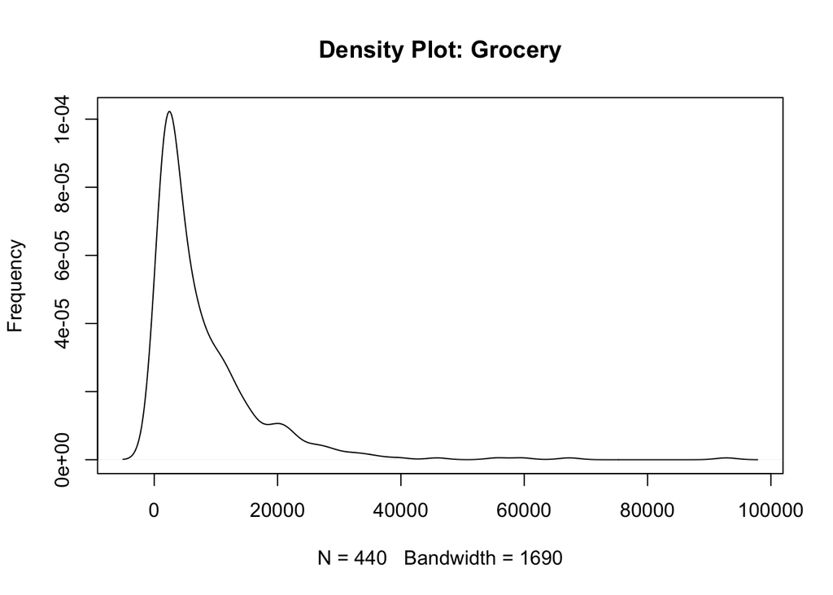

```r
plot(density(wholesale_customers$Grocery), main = "Density Plot: Grocery", ylab = "Frequency")
```

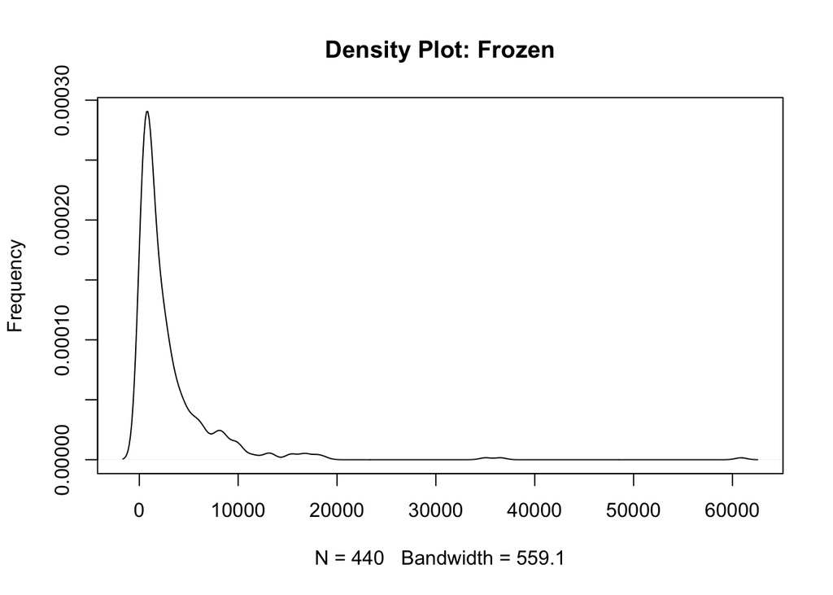

```r
plot(density(wholesale_customers$Frozen), main = "Density Plot: Frozen", ylab = "Frequency")
```

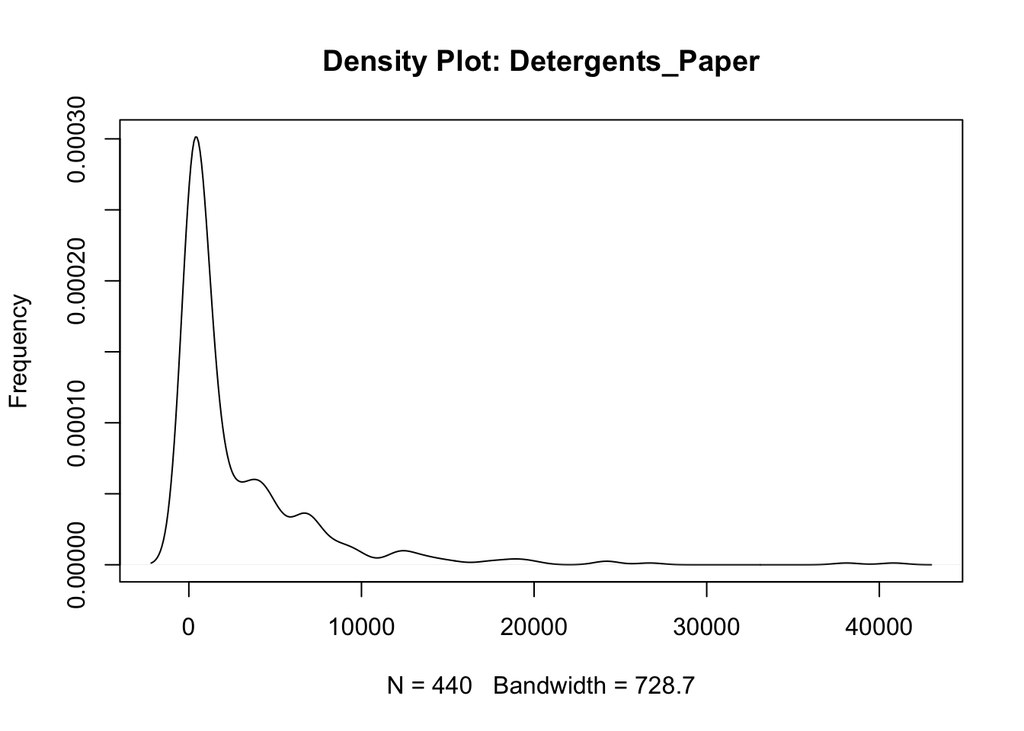

```r
plot(density(wholesale_customers$Detergents_Paper), main = "Density Plot: Detergents_Paper", ylab = "Frequency")
```

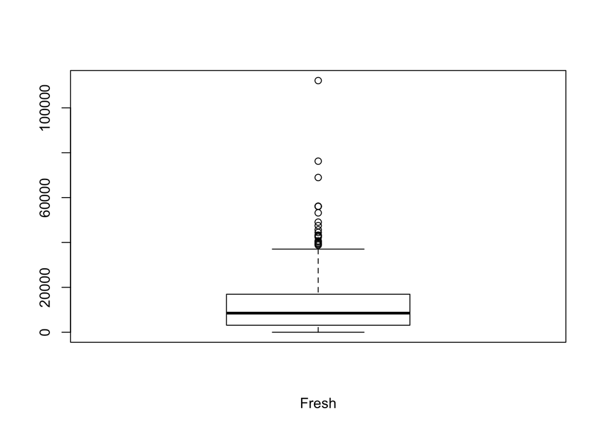

```r
# boxplot para ver outliers en cada variable
boxplot(wholesale_customers$Fresh, xlab = "Fresh")
```

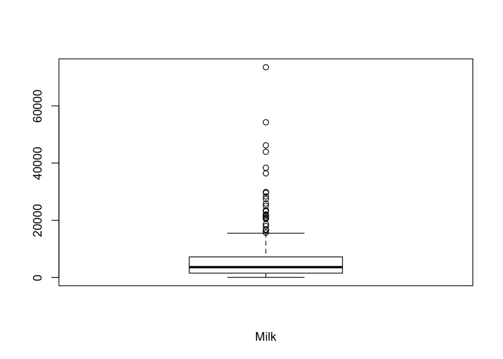

```r
boxplot(wholesale_customers$Milk, xlab = "Milk")
```

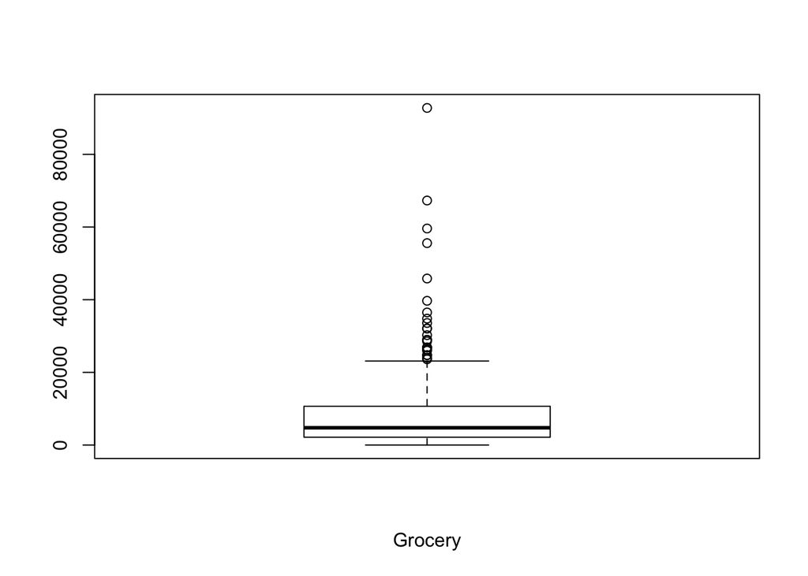

```r
boxplot(wholesale_customers$Grocery, xlab = "Grocery")
```

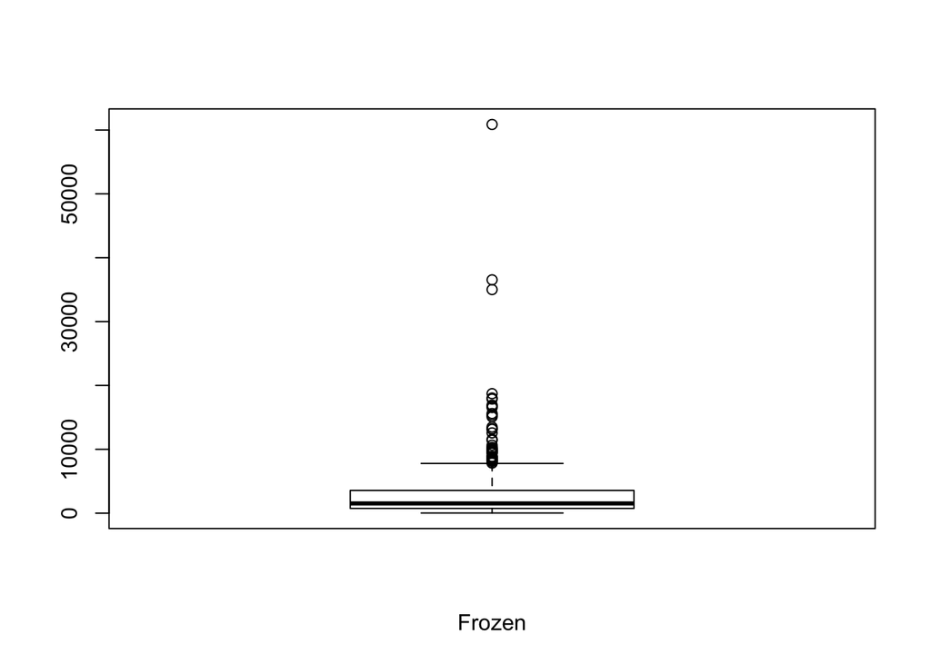

```r
boxplot(wholesale_customers$Frozen, xlab = "Frozen")
```

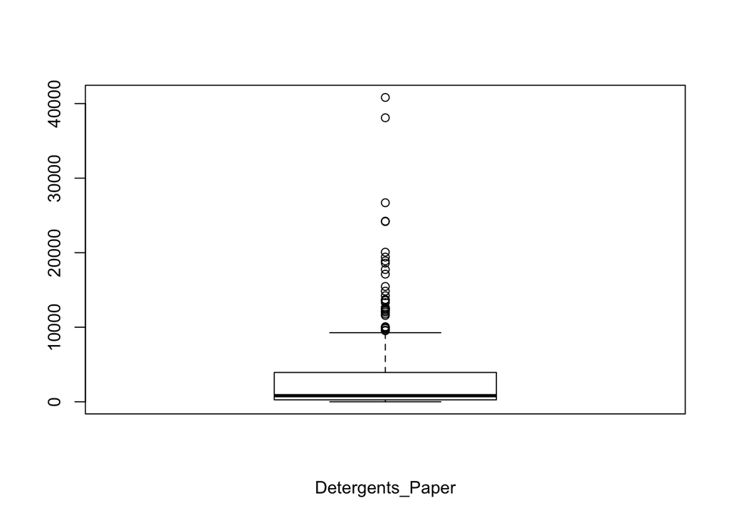

```r
boxplot(wholesale_customers$Detergents_Paper, xlab= "Detergents_Paper")
```

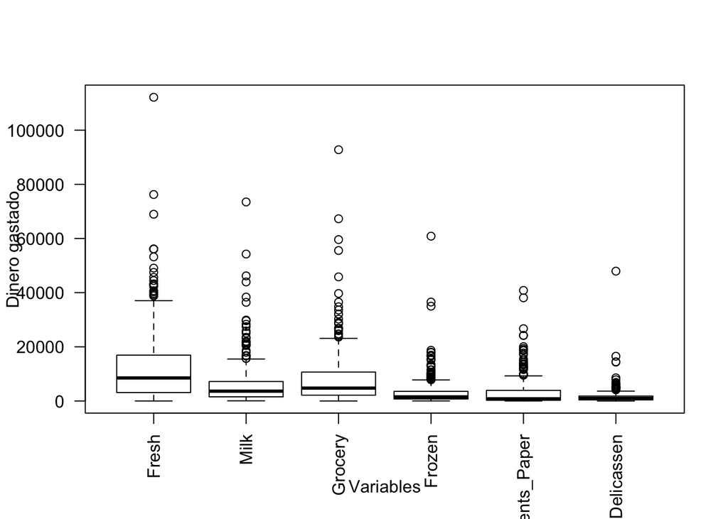

```r
# boxplot de todas las variables juntas
# aqui podemos ver como todas las variables tienen outliers.
boxplot(wholesale_customers[-c(1,2)],
        xlab = "Variables",
        ylab = "Dinero gastado",
        options(scipen = 1),
        las = 2)
```

Las variables Region y Channel, son variables categóricas nominales, las voy a convertir a factor.

```r
wholesale_customers$Channel = factor(wholesale_customers$Channel,
                                     levels = c(1,2),
                                     labels = c("Horeca", "Retail"))

wholesale_customers$Region = factor(wholesale_customers$Region,
                                     levels = c(1,2,3),
                                     labels = c("Lisbon", "Oporto", "Other Region"))

# confirmo que ahora tengo variables de tipo factor
glimpse(wholesale_customers)
```

```
## Observations: 440
## Variables: 8
## $ Channel          <fct> Retail, Retail, Retail, Horeca, Retail, Retail,…
## $ Region           <fct> Other Region, Other Region, Other Region, Other…
## $ Fresh            <int> 12669, 7057, 6353, 13265, 22615, 9413, 12126, 7…
## $ Milk             <int> 9656, 9810, 8808, 1196, 5410, 8259, 3199, 4956,…
## $ Grocery          <int> 7561, 9568, 7684, 4221, 7198, 5126, 6975, 9426,…
## $ Frozen           <int> 214, 1762, 2405, 6404, 3915, 666, 480, 1669, 42…
## $ Detergents_Paper <int> 2674, 3293, 3516, 507, 1777, 1795, 3140, 3321, …
## $ Delicassen       <int> 1338, 1776, 7844, 1788, 5185, 1451, 545, 2566, …
```

4. Utilizando barplot cree un gráfico de los atributos del dataset, observe las correlaciones entre atributos  
   Voy a realizar un ggpairs que puede ser más fácil para visualizar y entender los datos

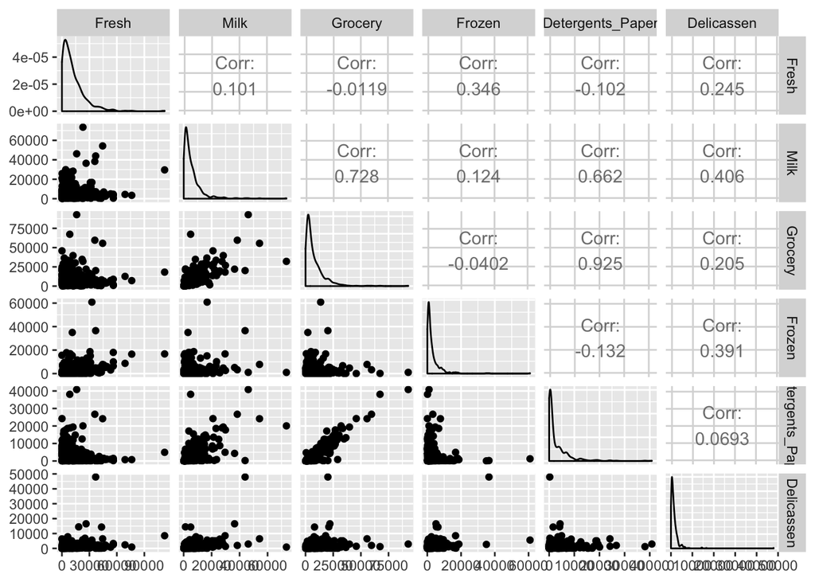

```r
ggpairs(wholesale_customers[-c(1,2)], progress = F)
```

5. Explique el siguiente gráfico:
- Antes de este gráfico convertí a variables tipo factor las variables de Channel y de Region porque son variables categóricas nominales, al convertirlas a factor, podemos clasificar basado en sus valores.

El siguiente gráfico muestra la cantidad de ventas por producto filtrando por canal, a la izquierda vemos todas las ventas de productos por el canal Horeca, y a la derecha vemos las ventas por producto del sector Retail.

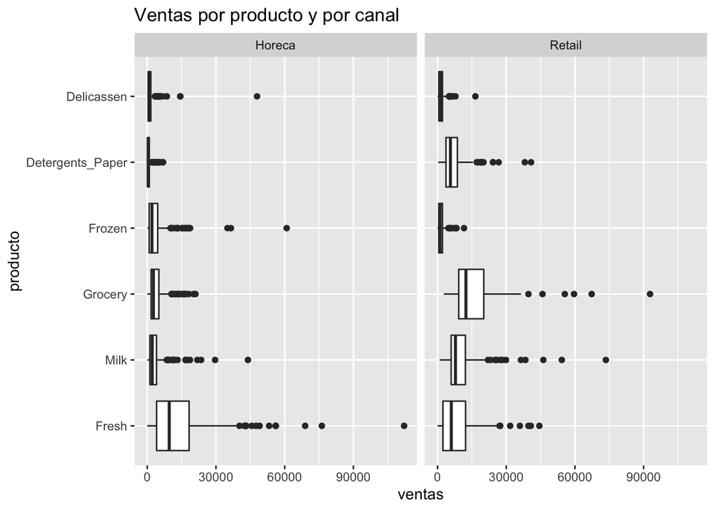

```r
bxplt <- ggplot(data = melt(data = wholesale_customers),
                aes(x = variable, y = value))
bxplt <- bxplt + geom_boxplot()
bxplt <- bxplt + facet_wrap(~Channel)
bxplt <- bxplt + coord_flip()
bxplt <- bxplt + labs(x = 'producto', y = 'ventas')
bxplt <- bxplt + ggtitle('Ventas por producto y por canal')
bxplt
```

6. Cree un modelo de agrupación K- Means  
   Para agrupar a los clientes con base al consumo, vamos a utilizar solo las variables Fresh, Milk, Grocery, Frozen, Detergents_Paper y Delicassen.  
   En este caso, vamos a intentar agrupar los clientes en 5 grupos diferentes.

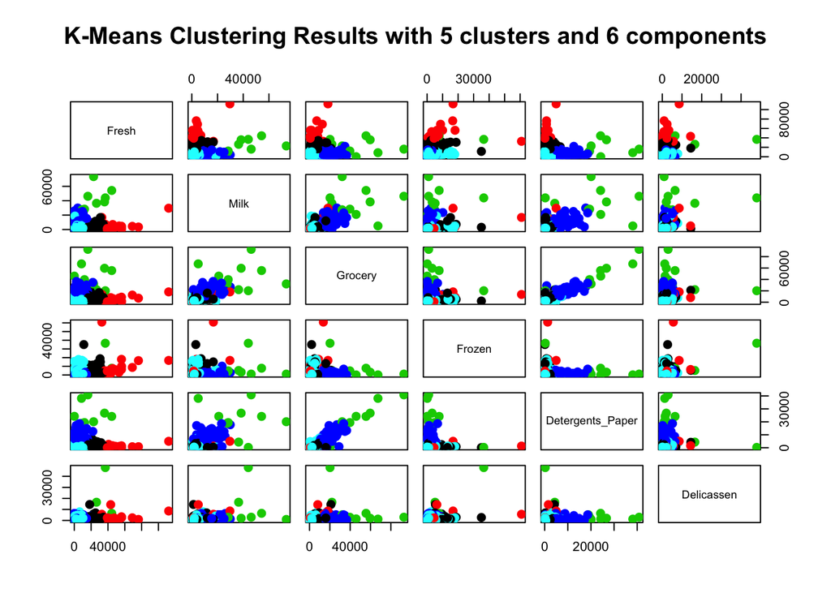

```r
set.seed(24)

# 5 Centroides utilizando k-means
modelo_agrupacion <- kmeans(wholesale_customers[,c(3:8)], centers = 5)

# predecir utilizando el modelo para agregar una variable nueva llamada 'cluster' al conjunto de datos
wholesale_customers$cluster <- modelo_agrupacion$cluster

# convertir la variable nueva a un factor
wholesale_customers$cluster <- factor(wholesale_customers$cluster)

plot(wholesale_customers[,c(3:8)],
     col = (wholesale_customers$cluster),
     main = "K-Means Clustering Results with 5 clusters and 6 components",
     pch = 20,
     cex = 2)
```

6. Realice al menos 3 modelos cambiando los centroides
1. Probando con 3 centroides

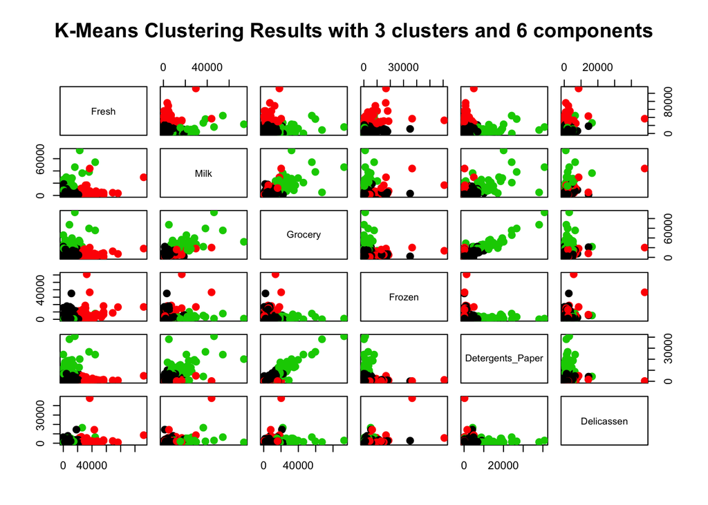

```r
set.seed(24)

# 3 Centroides utilizando k-means
modelo_agrupacion_3 <- kmeans(wholesale_customers[,c(3:8)], centers = 3)

# predecir utilizando el modelo para agregar una variable nueva llamada 'cluster' al conjunto de datos
wholesale_customers$cluster_3 <- modelo_agrupacion_3$cluster

# convertir la variable nueva a un factor
wholesale_customers$cluster_3 <- factor(wholesale_customers$cluster_3)

plot(wholesale_customers[,c(3:8)],
     col = (wholesale_customers$cluster_3),
     main = "K-Means Clustering Results with 3 clusters and 6 components",
     pch = 20,
     cex = 2)
```

2. Probando con 2 centroides

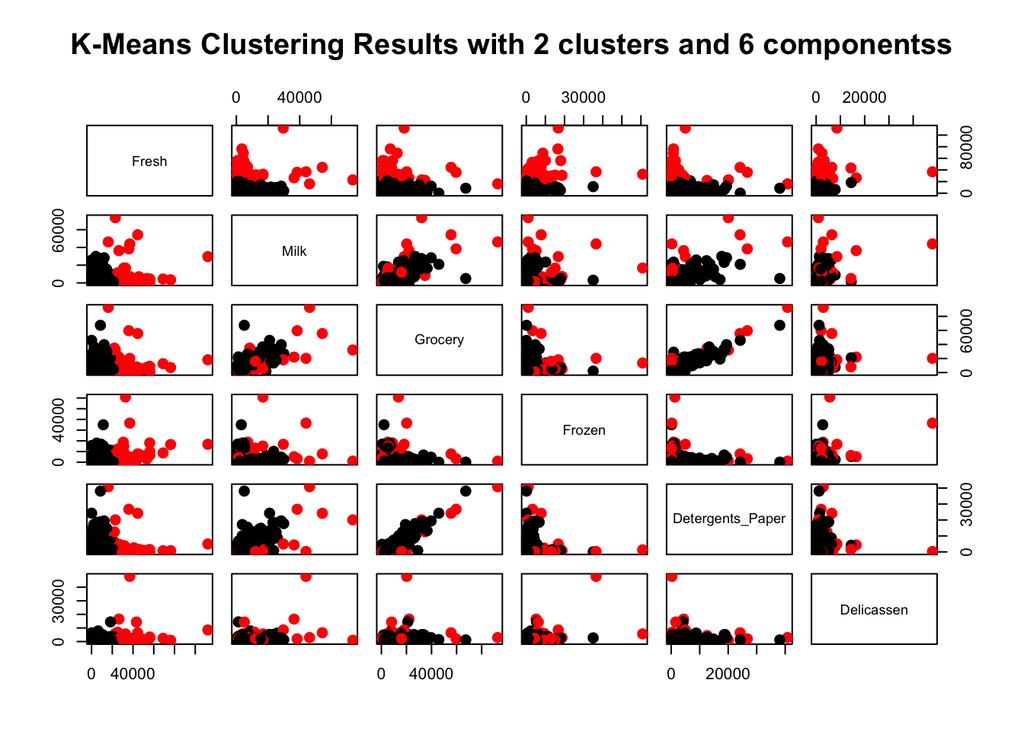

```r
set.seed(24)

# 2 Centroides utilizando k-means
modelo_agrupacion_2 <- kmeans(wholesale_customers[,c(3:8)], centers = 2)

# predecir utilizando el modelo para agregar una variable nueva llamada 'cluster' al conjunto de datos
wholesale_customers$cluster_2 <- modelo_agrupacion_2$cluster

# convertir la variable nueva a un factor
wholesale_customers$cluster_2 <- factor(wholesale_customers$cluster_2)

plot(wholesale_customers[,c(3:8)],
     col = (wholesale_customers$cluster_2),
     main = "K-Means Clustering Results with 2 clusters and 6 componentss",
     pch = 20,
     cex = 2)
```

3. Probando con 4 centroides

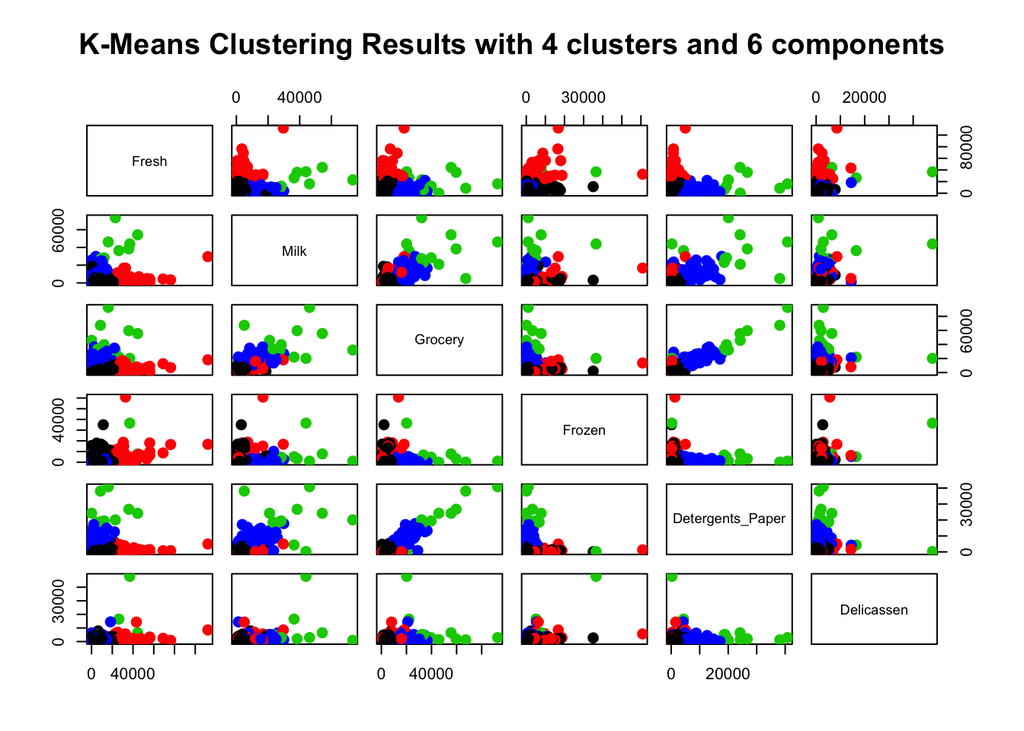

```r
set.seed(24)

# 4 Centroides utilizando k-means
modelo_agrupacion_4 <- kmeans(wholesale_customers[,c(3:8)], centers = 4)

# predecir utilizando el modelo para agregar una variable nueva llamada 'cluster' al conjunto de datos
wholesale_customers$cluster_4 <- modelo_agrupacion_4$cluster

# convertir la variable nueva a un factor
wholesale_customers$cluster_4 <- factor(wholesale_customers$cluster_4)

plot(wholesale_customers[,c(3:8)],
     col = (wholesale_customers$cluster_4),
     main = "K-Means Clustering Results with 4 clusters and 6 components",
     pch = 20,
     cex = 2)
```

7. Evaluación del modelo

Sin realizar ninguna modificación a los datos, cuando hago 5 clusters, puedo notar que 2 grupos tienen muy pocos elementos, el cluster 2 con 23 observaciones y el grupo 3 con solo 10 observaciones.

Esto se puede deber a que tengo outliers en todas las columnas, se puede probar eliminando los outliers para confirmar si obtengo una división más pareja en los grupos.

```r
by(wholesale_customers, wholesale_customers$cluster, summary)
```

```
## wholesale_customers$cluster: 1
##    Channel            Region       Fresh            Milk
##  Horeca:83   Lisbon      :18   Min.   :11314   Min.   :  134
##  Retail:21   Oporto      :11   1st Qu.:17053   1st Qu.: 1468
##              Other Region:75   Median :19906   Median : 2974
##                                Mean   :21200   Mean   : 3886
##                                3rd Qu.:25100   3rd Qu.: 5292
##                                Max.   :34454   Max.   :16687
##     Grocery          Frozen      Detergents_Paper   Delicassen    cluster
##  Min.   :    3   Min.   :  118   Min.   :   3.0   Min.   :   57   1:104
##  1st Qu.: 2112   1st Qu.: 1052   1st Qu.: 241.0   1st Qu.:  608   2:  0
##  Median : 3726   Median : 2536   Median : 499.5   Median : 1147   3:  0
##  Mean   : 5139   Mean   : 4120   Mean   :1131.5   Mean   : 1690   4:  0
##  3rd Qu.: 7225   3rd Qu.: 5134   3rd Qu.:1475.2   3rd Qu.: 2238   5:  0
##  Max.   :21042   Max.   :35009   Max.   :6707.0   Max.   :14472
##  cluster_3 cluster_2 cluster_4
##  1:68      1:69      1:67
##  2:36      2:35      2:35
##  3: 0                3: 0
##                      4: 2
##
##
## --------------------------------------------------------
## wholesale_customers$cluster: 2
##    Channel            Region       Fresh             Milk
##  Horeca:21   Lisbon      : 3   Min.   : 32717   Min.   :  286
##  Retail: 2   Oporto      : 1   1st Qu.: 39454   1st Qu.: 1871
##              Other Region:19   Median : 43088   Median : 3504
##                                Mean   : 49296   Mean   : 4984
##                                3rd Qu.: 54644   3rd Qu.: 4761
##                                Max.   :112151   Max.   :29627
##     Grocery          Frozen      Detergents_Paper   Delicassen
##  Min.   :  471   Min.   :  532   Min.   :  20.0   Min.   :    3.0
##  1st Qu.: 2366   1st Qu.: 1553   1st Qu.: 311.0   1st Qu.:  870.5
##  Median : 4252   Median : 4802   Median : 751.0   Median : 1819.0
##  Mean   : 5590   Mean   : 8286   Mean   : 962.3   Mean   : 2543.7
##  3rd Qu.: 7726   3rd Qu.: 8030   3rd Qu.:1189.5   3rd Qu.: 2452.0
##  Max.   :18148   Max.   :60869   Max.   :4948.0   Max.   :14351.0
##  cluster cluster_3 cluster_2 cluster_4
##  1: 0    1: 0      1: 0      1: 0
```

[output cut: 59 more lines]

```
##                                  Max.   :13970   Max.   :18664
##     Grocery          Frozen        Detergents_Paper   Delicassen
##  Min.   :  137   Min.   :   47.0   Min.   :   3.0   Min.   :   3.0
##  1st Qu.: 1728   1st Qu.:  641.5   1st Qu.: 208.5   1st Qu.: 317.5
##  Median : 3007   Median : 1341.0   Median : 477.0   Median : 689.0
##  Mean   : 4092   Mean   : 2459.7   Mean   :1214.1   Mean   : 990.6
##  3rd Qu.: 6107   3rd Qu.: 2933.5   3rd Qu.:1679.5   3rd Qu.:1365.5
##  Max.   :12822   Max.   :17866.0   Max.   :7271.0   Max.   :7844.0
##  cluster cluster_3 cluster_2 cluster_4
##  1:  0   1:223     1:223     1:209
##  2:  0   2:  0     2:  0     2:  0
##  3:  0   3:  0               3:  0
##  4:  0                       4: 14
##  5:223
##
```

Se prueba eliminando los outliers a ver si eso da algo más distribuido y luego se corre de nuevo el k-means sobre los datos sin outliers.  
Los valores por los que estoy filtrando, son valores que basado en el boxplot de cada variable me parece que eliminan los outliers más lejanos al resto de datos.

```r
# al aplicar el filter se eliminan el 5% de los datos originales
wholesale_no_outliers <- wholesale_customers %>% filter(Fresh <= 55000,
                                                        Milk <= 30000,
                                                        Grocery <= 40000,
                                                        Frozen <= 20000,
                                                        Detergents_Paper <= 15000)

# elimino variables de cluster que hay en el dataset original
wholesale_no_outliers <- wholesale_no_outliers[, c(1:8)]

set.seed(24)

# 5 Centroides utilizando k-means
modelo_agrupacion_no_outliers <- kmeans(wholesale_no_outliers[,c(3:8)], centers = 5)

# predecir utilizando el modelo para agregar una variable nueva llamada 'cluster' al conjunto de datos
wholesale_no_outliers$cluster <- modelo_agrupacion_no_outliers$cluster

# convertir la variable nueva a un factor
wholesale_no_outliers$cluster <- factor(wholesale_no_outliers$cluster)
```

Comparemos dos gráficos de dispersión con los clusters antes y después de quitar los outliers. Como se puede observar en el segundo gráfico, los clusters se encuentran menos aglomerados y es más fácil determinar los integrantes de cada grupo.

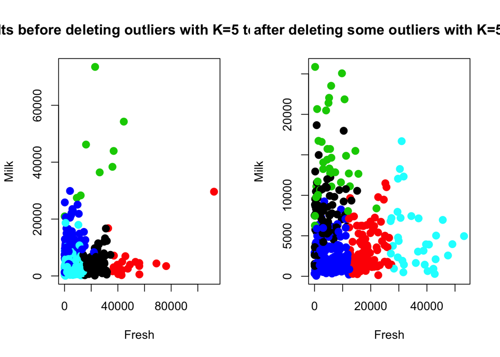

```r
par(mfrow=c(1,2))
plot(wholesale_customers[,c(3,4)],
     col = (wholesale_customers$cluster),
     main = "Clustering Results before deleting outliers with K=5 testing 6 components",
     pch = 20,
     cex = 2)

plot(wholesale_no_outliers[,c(3,4)],
     col = (wholesale_no_outliers$cluster),
     main = "Clustering Results after deleting some outliers with K=5 testing 6 components",
     pch = 20,
     cex = 2)
```

```r
par("mfrow")
```

```
## [1] 1 2
```

```r
by(wholesale_no_outliers, wholesale_no_outliers$cluster, summary)
```

```
## wholesale_no_outliers$cluster: 1
##    Channel            Region       Fresh              Milk
##  Horeca:24   Lisbon      :13   Min.   :    9.0   Min.   : 1275
##  Retail:59   Oporto      : 6   1st Qu.:  987.5   1st Qu.: 5485
##              Other Region:64   Median : 2932.0   Median : 7504
##                                Mean   : 3974.8   Mean   : 7594
##                                3rd Qu.: 5881.5   3rd Qu.: 9290
##                                Max.   :15168.0   Max.   :18664
##     Grocery          Frozen     Detergents_Paper   Delicassen   cluster
##  Min.   : 1660   Min.   :  25   Min.   :   93    Min.   :   3   1:83
##  1st Qu.: 8568   1st Qu.: 300   1st Qu.: 3464    1st Qu.: 303   2: 0
##  Median :10704   Median : 799   Median : 4515    Median :1215   3: 0
##  Mean   :10866   Mean   :1303   Mean   : 4663    Mean   :1369   4: 0
##  3rd Qu.:12898   3rd Qu.:1680   3rd Qu.: 6371    3rd Qu.:1847   5: 0
##  Max.   :22272   Max.   :6269   Max.   :10069    Max.   :7844
## --------------------------------------------------------
## wholesale_no_outliers$cluster: 2
##    Channel            Region       Fresh            Milk
##  Horeca:78   Lisbon      :17   Min.   :12126   Min.   :  134
##  Retail:22   Oporto      :11   1st Qu.:15529   1st Qu.: 1372
##              Other Region:72   Median :18044   Median : 2732
##                                Mean   :18501   Mean   : 3383
##                                3rd Qu.:21142   3rd Qu.: 4776
##                                Max.   :27329   Max.   :11487
##     Grocery          Frozen        Detergents_Paper   Delicassen
##  Min.   :    3   Min.   :  118.0   Min.   :   3.0   Min.   :   57.0
##  1st Qu.: 2011   1st Qu.:  887.5   1st Qu.: 241.0   1st Qu.:  568.5
##  Median : 3444   Median : 2206.5   Median : 532.5   Median : 1001.0
##  Mean   : 4718   Mean   : 3192.4   Mean   :1103.7   Mean   : 1575.1
##  3rd Qu.: 6408   3rd Qu.: 4276.0   3rd Qu.:1475.2   3rd Qu.: 2084.2
##  Max.   :21042   Max.   :11559.0   Max.   :6707.0   Max.   :14472.0
##  cluster
##  1:  0
##  2:100
##  3:  0
##  4:  0
##  5:  0
##
## --------------------------------------------------------
## wholesale_no_outliers$cluster: 3
```

[output cut: 45 more lines]

```
##                                Max.   :53205   Max.   :16687
##     Grocery          Frozen      Detergents_Paper   Delicassen
##  Min.   :  471   Min.   :  287   Min.   :  20.0   Min.   :    3.0
##  1st Qu.: 2619   1st Qu.: 1364   1st Qu.: 189.0   1st Qu.:  872.8
##  Median : 5072   Median : 3029   Median : 511.5   Median : 1445.0
##  Mean   : 5791   Mean   : 4526   Mean   : 987.6   Mean   : 1977.8
##  3rd Qu.: 7922   3rd Qu.: 5788   3rd Qu.:1090.5   3rd Qu.: 2248.5
##  Max.   :16966   Max.   :18711   Max.   :4621.0   Max.   :14351.0
##  cluster
##  1: 0
##  2: 0
##  3: 0
##  4: 0
##  5:34
##
```

Luego de eliminar los outliers se observa como los clusters tienen una distribución más equitativa de observaciones.

8. Desarolle al menos 5 conclusiones sobre los grupos realizados  
   NOTA: Las conclusiones de esta tarea se realizan basado en el modelo el k-means aplicado luego de eliminar los outliers.(el k-means del paso anterior)

Para el siguiente gráfico se agrupó el dataset por cluster y se calculó el promedio de consumo de cada variable, para luego compararlas.

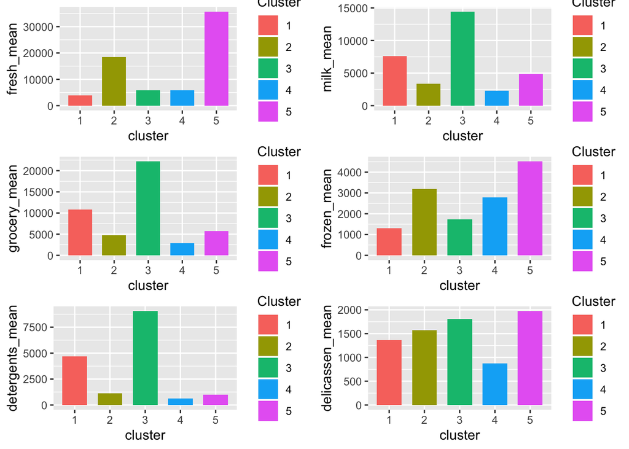

```r
clusters_df <- wholesale_no_outliers %>%
  group_by(cluster) %>%
  summarise(fresh_mean = mean(Fresh),
            milk_mean = mean(Milk),
            grocery_mean = mean(Grocery),
            frozen_mean = mean(Frozen),
            detergents_mean = mean(Detergents_Paper),
            delicassen_mean = mean(Delicassen))

fresh_plt <- ggplot(clusters_df, aes(x = cluster, y = fresh_mean)) +
  labs(fill = "Cluster") +
  geom_bar(
    aes(fill = clusters_df$cluster),
    stat = "identity",
    position = position_dodge(0.8),
    width = 0.7)

milk_plot <- ggplot(clusters_df, aes(x = cluster, y = milk_mean)) +
  labs(fill = "Cluster") +
  geom_bar(
    aes(fill = clusters_df$cluster),
    stat = "identity",
    position = position_dodge(0.8),
    width = 0.7)

grocery_plot <- ggplot(clusters_df, aes(x = cluster, y = grocery_mean)) +
  labs(fill = "Cluster") +
  geom_bar(
    aes(fill = clusters_df$cluster),
    stat = "identity",
    position = position_dodge(0.8),
    width = 0.7)

frozen_plot <- ggplot(clusters_df, aes(x = cluster, y = frozen_mean)) +
  labs(fill = "Cluster") +
  geom_bar(
    aes(fill = clusters_df$cluster),
    stat = "identity",
    position = position_dodge(0.8),
    width = 0.7)

detergents_plot <- ggplot(clusters_df, aes(x = cluster, y = detergents_mean)) +
  labs(fill = "Cluster") +
  geom_bar(
    aes(fill = clusters_df$cluster),
    stat = "identity",
    position = position_dodge(0.8),
    width = 0.7)

delicassen_plot <- ggplot(clusters_df, aes(x = cluster, y = delicassen_mean)) +
  labs(fill = "Cluster") +
  geom_bar(
    aes(fill = clusters_df$cluster),
    stat = "identity",
    position = position_dodge(0.8),
    width = 0.7)

grid.arrange(fresh_plt,
             milk_plot,
             grocery_plot,
             frozen_plot,
             detergents_plot,
             delicassen_plot,
             ncol = 2,
             nrow = 3)
```

- **Cluster 1: 83 observaciones**
  - La mayoría de sus observaciones son del channel Retail(59).
  - La mayoría pertenece a Other Region(64)
  - El consumo de productos frescos es el más bajo de todos los clusters.
  - Es el segundo cluster que más consume productos lácteos.
  - Es el segundo cluster que más consume comestibles(grocery)
  - Es el que menor cantidad de productos congelados consume
  - Segundo lugar en la compra de detergentes y papel
  - Alto consumo de productos tipo delicatessen
- **Cluster 2: 100 observaciones**
  - La mayoría de observaciones son del channel Horeca y de Other regions.
  - Segundo en el consumo de productos frescos
  - Bajo consumo de productos lácteos
  - Bajo consumo de comestibles(grocery)
  - Segundo en consumo de productos congelados
  - Muy bajo consumo de detergentes y papel
  - Alto consumo de productos tipo delicatessen
- **Cluster 3: 37 observaciones**
  - La mayoría de observaciones son del channel Retail y de Other regions.
  - Bajo consumo de productos frescos
  - El grupo que más consume productos lácteos
  - El grupo que más consume comestibles(grocery)
  - Bajo consumo de productos congelados
  - El grupo que más consume detergentes y papel
  - Alto consumo de productos tipo delicatessen
- **Cluster 4: 164 observaciones**
  - La mayoría de observaciones son del channel Horeca y de Other regions.
  - Muy bajo consumo de productos frescos
  - Muy bajo consumo de productos lácteos
  - Muy bajo consumo de comestibles(grocery)
  - Alto consumo de productos congelados
  - Muy bajo consumo de detergentes y papel
  - El grupo que menos consume productos tipo delicatessen
- **Cluster 5: 34 observaciones**
  - La mayoría de observaciones son del channel Horeca y de Other regions.
  - Es el cluster que más consume productos frescos
  - Bajo consumo de productos lácteos
  - Bajo consumo de comestibles(grocery)
  - Muy alto consumo de productos congelados
  - Muy bajo consumo de detergentes y papel
  - El grupo que más consume productos tipo delicatessen